# Biostatistician Programmer Assessment

Ruixuan Ma

11/14/2019

If interested please go to my [GitHub repository](https://github.com/ruixuanma/HeartAttack_Commute45) to explore more details about datasets and code

## 0. Packages Installation

The beginning of the task is to install packages we need for latter process

```r
install.packages("tigris", repos = "http://cran.us.r-project.org")
install.packages("blscrapeR", repos = "http://cran.us.r-project.org")

library(sp)
library(tidyverse)
library(dplyr)
library(ggplot2)
library(tigris)
library(blscrapeR)
library(leaflet)
```

## 1. The Data

##### 1. Go to https://data.census.gov/

##### 2. Extract population of each county from table S0101: Age and Sex

##### i) Make sure the time from is consistent with the time frame of the data 2012-2016

##### 3. Describe the data.

```r
library(dplyr)

# go to https://data.census.gov/ to extract population data for each county of FL from table S0101: Age and Sex with 2012-2016 5-years estimate
rawPop <- read.csv('FLpopulation.csv')

# keep necessary columns, in order to clearly and concisely show the data table resuts when calling
rawPop_keep <- rawPop %>%
  select("GEO_ID", "NAME", "S0101_C01_001E", "S0101_C01_001M", "S0101_C01_002E", "S0101_C01_002M")

#remove irrelevant rows
pop_rm_rows <- rawPop[-c(1, 69), ]

#change the values for GEO_ID variable, in order to match with countyFIPS on latter process, and convert factor to numeric
pop_rm_rows$GEO_ID <- as.numeric(gsub("0500000US", "", as.character(pop_rm_rows$GEO_ID)))

#only keep the nessesary variables and rename them
dt_pop <- pop_rm_rows %>%
  select("GEO_ID", "NAME", "S0101_C01_001E") %>%
  rename(countyFIPS = GEO_ID) %>%
  rename(countyPop = S0101_C01_001E)

#call the head of raw population data (without the rest hundreds of sex, age, margin of error variables)
knitr::kable(head(rawPop_keep), caption = "Head of Raw Population Data Table")
```

Head of Raw Population Data Table

| GEO_ID | NAME | S0101_C01_001E | S0101_C01_001M | S0101_C01_002E | S0101_C01_002M |
| --- | --- | --- | --- | --- | --- |
| id | Geographic Area Name | Total!!Estimate!!Total population | Total!!Margin of Error!!Total population | Total!!Estimate!!AGE!!Under 5 years | Total!!Margin of Error!!AGE!!Under 5 years |
| 0500000US12001 | Alachua County, Florida | 256581 | ***** | 5.5 | 0.1 |
| 0500000US12003 | Baker County, Florida | 27312 | ***** | 6.2 | 0.6 |
| 0500000US12005 | Bay County, Florida | 178361 | ***** | 6.3 | 0.1 |
| 0500000US12007 | Bradford County, Florida | 26919 | ***** | 5.5 | 0.1 |
| 0500000US12009 | Brevard County, Florida | 560683 | ***** | 4.8 | 0.1 |

Acquired from U.S. Census Bureau, 2012-2016 American Community Survey 5-years Estimates, the data table above shows the population of all Florida counties for total, different gender, and different age levels during 2012-2016. We only call the first part of our data set since the complete data set contains 69 observations and 218 variables, which cannot be concisely displayed in the R Markdown file. For this data set, the degree of uncertainty for an estimate arising from sampling variability is represented through the use of margin of error. The values shown in the data set 90 percent margin of error. The margin of error can be interpreted roughly as providing a 90 percent probability that the interval defined by the estimate minus the margin of error and the estimate plus the margin of error (the lower and upper confidence bounds) contains the true value.

## 2. Calculate Rates

##### 3. Calculate the percentage of people who spend 45+ minutes commuting to work in the Sylvester Catchment Area (Miami-Dade, Broward, Palm Beach, and Monroe counties).

##### 4. Repeat step 3 for heart attack hospitalizations

##### i) hint: this data has numbers per year so get the average for a 5 year estimate

##### 5. Report

```r
library(tidyverse)
library(dplyr)

# read commute over 45 min data
dt_com45 <- read.csv('commuteTime45_2012_16.csv')

# convert factor to numeric
dt_com45$Value <- as.numeric(gsub(",", "", as.character(dt_com45$Value)))


# read heart attack data
dt_ha <- read.csv('heartAttackER_2012_16.csv')

# convert factor to numeric
dt_ha$Value <- as.numeric(gsub(",", "", as.character(dt_ha$Value)))


# get mean of numbers of people in each county for 5 years estimate for grouped heartAttack data
mean_5year<- dt_ha %>%
  group_by(County) %>%
  summarize(Value = mean(Value))

# merge com45 data and mean of 5 years data
merge_45_ha <- merge(dt_com45, mean_5year, by = "County", all = TRUE)

# merge population data for each county between 2012-2016 with another merged dataset
mergeAll <- merge(merge_45_ha, dt_pop, by = "countyFIPS", all = TRUE)

# convert factor to numeric
mergeAll$countyPop <- as.numeric(as.character(mergeAll$countyPop))

# rename columns, keep and reorder those colomns we want, canculate rounded rates for heart attack ang long time commute
mergeDt <- mergeAll %>%
  rename(num_45 = Value.x) %>%
  rename(num_ha = Value.y) %>%
  select("stateFIPS","State","countyFIPS", "NAME", "Year", "countyPop", "num_45", "num_ha") %>%
  mutate(perc_ha = num_ha / countyPop * 100) %>%
  mutate(perc_45 = num_45 / countyPop * 100) %>%
  mutate(hospRate = round(perc_ha, 2)) %>%
  mutate(commRate = round(perc_45, 2)) %>%
  select("stateFIPS","State","countyFIPS", "NAME", "Year", "countyPop", "num_ha", "num_45", "hospRate", "commRate")

# filter specified rows and columns and report
reportDt <- mergeDt %>%
  filter(countyFIPS == 12011 | countyFIPS ==12086 | countyFIPS == 12087 | countyFIPS == 12099) %>%
  select("NAME", "hospRate", "commRate")

knitr::kable(reportDt, caption = "Table of Rates")
```

Table of Rates

| NAME | hospRate | commRate |
| --- | --- | --- |
| Broward County, Florida | 0.18 | 7.10 |
| Miami-Dade County, Florida | 0.20 | 8.19 |
| Monroe County, Florida | 0.22 | 3.58 |
| Palm Beach County, Florida | 0.19 | 4.88 |

## 3. Graphing Correlates of Commute Time and Heart Attack

##### 1. Create a scatter plot to examine the relationship between the number of people who commute 45+ minutes and heart attack hospitalizations for all florida counties.

##### 2. According to your plot, what can you infer about the relationship between these two factors?

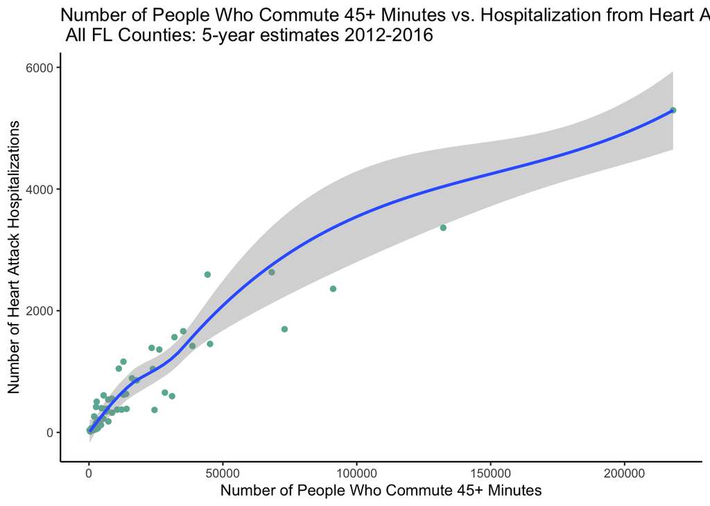

```r
library(ggplot2)

# create scatter plot for exploring relationship between long commute time and heart attack
com_ha_plot <- ggplot(mergeDt, aes(x = num_45 , y = num_ha)) + geom_point(color = "#69b3a2") +
  labs(title = 'Number of People Who Commute 45+ Minutes vs. Hospitalization from Heart Attack \n All FL Counties: 5-year estimates 2012-2016',
       x = 'Number of People Who Commute 45+ Minutes', y = "Number of Heart Attack Hospitalizations") +
  geom_smooth(method = "loess", formula = y ~ x) +
  theme_classic()

plot(com_ha_plot)
```

According to the scatter plot shown above, the points and regression line show an uphill pattern as we move from left to right in the scatter plot, this indicates a positive correlation between long commute time and heart attack hospitalization. From this graph, we can infer that longer commute times are associated with increases in the number of heart attack hospitalization.

## 4. Mapping Estimates

##### 1. Calculate the ratio of heart attack hospitalizations by number of people who commute 45+ minutes for all Florida counties.

##### 2. Map those rates. hint: you can download county boundary files using the tigris pacakge and the ggplot2, maps, leaflet packages for mapping.

```r
#load the tigris package for mapping
library(tigris)

#download Florida counties boundary files using tigris package
fl <- counties(12, cb = TRUE, year = 2016)
```

```r
# load the packages we need for mapping
library(sp)
library(tidyverse)
library(dplyr)
library(ggplot2)
library(tigris)
library(blscrapeR)
library(leaflet)

#calculate the rounded ratio of heart attack / long time commute for all FL counties.
mapRatio <- mergeDt %>%
  mutate(ratio_unround = num_ha / num_45) %>%
  mutate(ratio = round(ratio_unround, 3)) %>%
  select("countyFIPS", "ratio") %>%
  rename(GEOID = countyFIPS)

#convert numeric to character
mapRatio$GEOID = as.character(mapRatio$GEOID)

#merge ratio dataset with spatial object
leafmap <- geo_join(fl, mapRatio, by = "GEOID")

#format popup data for leaflet map and click the counties on map to check the specific ratio
popup_dat <- paste0("<strong>County: </strong>",
                    leafmap$NAME,
                    "<br><strong>Heart Attacks / Long Commute: </strong>",
                    leafmap$ratio)

# create palette function for ratio and set 6 bins
pal3 <- colorBin(palette="YlOrRd", domain=c(min(leafmap$ratio), max(leafmap$ratio)), bins = 6, na.color = NULL, pretty=FALSE, alpha = TRUE)

# mapping using leaflet with polygon for counties and legend with different bins
leaflet(data = leafmap) %>% addTiles() %>%
  addPolygons(fillColor = ~pal3(leafmap$ratio),
              fillOpacity = 1,
              color = "#BDBDC3",
              weight = 1,
              popup = popup_dat) %>%
  addLegend(pal = pal3,
            values  = leafmap$ratio,
            position = "bottomleft",
            title = "Heart Attacks / Long Commute ")
```

[interactive chart not shown]